# Week 1 using R

Soyeon Ahn, Ph.D.

# Install and load required packages

```r
> # install three R packages first.
> install.packages(c("psych", "Hmisc", "graphics", "car", "utils"), dependencies=TRUE)
> # load all three packages before running the model.
> require("psych")
> require("Hmisc")
> require("graphics")
> require("car")
> require("utils")
```

# Example dataset

Let’s assume that we are interested in knowing whether homework helps one’s learning experience. Research question is “Does math homework help one’s school performance?”.

Datafile (L1.txt) contains two variables, mathhome and mathach. Two variables are 1) mathhome (IV, X): time spent on math homework per week (in hours), and 2) mathach (DV, Y): math achievement test score (T scores, M = 50, SD = 10).

```r
> # Read dataset and save it as "l1".
> l1=read.table("l1.txt", sep="", header=TRUE, quote="\"'")
>
> names(l1) #show variable names
TRUE [1] "mathhome" "mathach"
> head(l1) # inspect the dataset
```

|  | mathhome | mathach |
| --- | --- | --- |
| 1 | 2 | 54 |
| 2 | 0 | 53 |
| 3 | 4 | 53 |
| 4 | 0 | 56 |
| 5 | 2 | 59 |
| 6 | 0 | 30 |

```r
> describe(l1) # descriptive statistics
TRUE l1
TRUE
TRUE  2  Variables      100  Observations
TRUE --------------------------------------------------------------------------------
TRUE mathhome
TRUE        n  missing distinct     Info     Mean      Gmd
TRUE      100        0        9    0.965      2.2    1.952
TRUE
TRUE lowest :  0  1  2  3  4, highest:  4  5  6  7 10
TRUE
TRUE Value         0    1    2    3    4    5    6    7   10
TRUE Frequency    19   19   25   16   11    6    2    1    1
TRUE Proportion 0.19 0.19 0.25 0.16 0.11 0.06 0.02 0.01 0.01
TRUE --------------------------------------------------------------------------------
TRUE mathach
TRUE        n  missing distinct     Info     Mean      Gmd      .05      .10
TRUE      100        0       40    0.999    51.41     12.8    31.90    37.00
TRUE      .25      .50      .75      .90      .95
TRUE    44.00    53.00    59.25    64.00    70.05
TRUE
TRUE lowest : 22 25 29 30 32, highest: 70 71 72 74 75
TRUE --------------------------------------------------------------------------------
>
> #####################################################################
```

WRITE-UP

Mathhome has a mean of 2.20 and a standard deviation of 1.81; math achieve has a mean of 51.41 and a standard deviation of 11.29.

# Correlation

```r
> rcorr(as.matrix(l1)) # correlations with significance levels
TRUE          mathhome mathach
TRUE mathhome     1.00    0.32
TRUE mathach      0.32    1.00
TRUE
TRUE n= 100
TRUE
TRUE
TRUE P
TRUE          mathhome mathach
TRUE mathhome          0.0012
TRUE mathach  0.0012
>
> #####################################################################
```

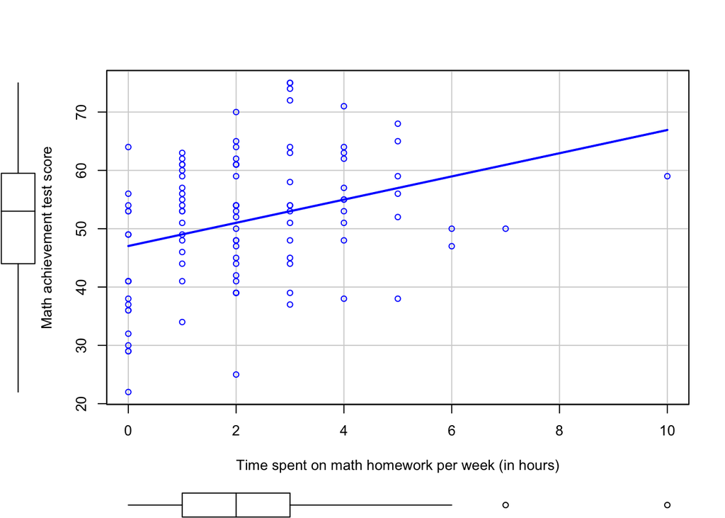

```r
> #####################################################################
> # scatterplot
> car::scatterplot(mathach~mathhome, data=l1, smooth=FALSE, xlab="Time spent on math homework per week (in hours)", ylab="Math achievement test score") #scatterplot using "car" package
```

```r
> #####################################################################
```

WRITE-UP

Correlation between mathhome and mathach was .32, which was found to be statistically significant (p = .001).